# Chiara homework week 11 day 2

```r
library(rpart)
library(rpart.plot)
library(tidyverse)

library(tidyverse)
titanic_set <- read_csv('data/titanic_decision_tree_data.csv')
shuffle_index <- sample(1:nrow(titanic_set))

# shuffle the data so class order isn't in order - need this for training/testing split later on
titanic_set <- titanic_set[shuffle_index, ]
```

# MVP

## QAuestion 1

Cleaning up the data is always the first step. Do the following:

```r
skimr::skim(titanic_set)
```

```
── Data Summary ────────────────────────
                           Values
Name                       titanic_set
Number of rows             1309
Number of columns          13
_______________________
Column type frequency:
  character                5
  numeric                  8
________________________
Group variables            None
```

|  | skim_variable | n_missing | complete_rate | min | max | empty | n_unique | whitespace |
| --- | --- | --- | --- | --- | --- | --- | --- | --- |
| 1 | name | 0 | 1.0000000 | 12 | 82 | 0 | 1307 | 0 |
| 2 | sex | 0 | 1.0000000 | 4 | 6 | 0 | 2 | 0 |
| 3 | ticket | 0 | 1.0000000 | 3 | 18 | 0 | 929 | 0 |
| 4 | cabin | 1014 | 0.2253629 | 1 | 15 | 0 | 186 | 0 |
| 5 | embarked | 2 | 0.9984721 | 1 | 1 | 0 | 3 | 0 |

|  | skim_variable | n_missing | complete_rate | mean | sd | p0 | p25 | p50 | p75 | p100 | hist |
| --- | --- | --- | --- | --- | --- | --- | --- | --- | --- | --- | --- |
| 1 | ...1 | 0 | 1.0000000 | 655.0000000 | 378.0200612 | 1.00 | 328.0000 | 655.0000 | 982.000 | 1309.0000 | ▇▇▇▇▇ |
| 2 | passenger_id | 0 | 1.0000000 | 655.0000000 | 378.0200612 | 1.00 | 328.0000 | 655.0000 | 982.000 | 1309.0000 | ▇▇▇▇▇ |
| 3 | pclass | 0 | 1.0000000 | 2.2948816 | 0.8378360 | 1.00 | 2.0000 | 3.0000 | 3.000 | 3.0000 | ▃▁▃▁▇ |
| 4 | age | 263 | 0.7990833 | 29.8811377 | 14.4134932 | 0.17 | 21.0000 | 28.0000 | 39.000 | 80.0000 | ▂▇▅▂▁ |
| 5 | sib_sp | 0 | 1.0000000 | 0.4988541 | 1.0416584 | 0.00 | 0.0000 | 0.0000 | 1.000 | 8.0000 | ▇▁▁▁▁ |
| 6 | parch | 0 | 1.0000000 | 0.3850267 | 0.8655603 | 0.00 | 0.0000 | 0.0000 | 0.000 | 9.0000 | ▇▁▁▁▁ |
| 7 | fare | 1 | 0.9992361 | 33.2954793 | 51.7586682 | 0.00 | 7.8958 | 14.4542 | 31.275 | 512.3292 | ▇▁▁▁▁ |
| 8 | survived | 418 | 0.6806723 | 0.3838384 | 0.4865925 | 0.00 | 0.0000 | 0.0000 | 1.000 | 1.0000 | ▇▁▁▁▅ |

```r
glimpse(titanic_set)
```

```
Rows: 1,309
Columns: 13
$ ...1         <dbl> 946, 528, 434, 154, 692, 727, 930, 1178, 828, 227, 927, 908, 962, 596, 863, 343, 359, 203,…
$ passenger_id <dbl> 528, 110, 16, 1045, 274, 309, 512, 760, 410, 1118, 509, 490, 544, 178, 445, 1234, 1250, 10…
$ pclass       <dbl> 1, 3, 2, 3, 1, 2, 3, 1, 3, 3, 3, 3, 2, 1, 3, 3, 3, 1, 3, 3, 3, 3, 2, 3, 3, 3, 3, 1, 3, 3, …
$ name         <chr> "Farthing, Mr. John", "Moran, Miss. Bertha", "Hewlett, Mrs. (Mary D Kingcome)", "Klasen, M…
$ sex          <chr> "male", "female", "female", "female", "male", "male", "male", "female", "female", "male", …
$ age          <dbl> NA, NA, 55, 36, 37, 30, NA, 33, NA, 23, 28, 9, 32, 50, NA, NA, NA, 47, NA, 13, NA, NA, 22,…
$ sib_sp       <dbl> 0, 1, 0, 0, 0, 1, 0, 0, 3, 0, 0, 1, 1, 0, 0, 1, 0, 1, 0, 0, 0, 0, 2, 0, 1, 0, 0, 0, 1, 0, …
$ parch        <dbl> 0, 0, 0, 2, 1, 0, 0, 0, 1, 0, 0, 1, 0, 0, 0, 9, 0, 0, 0, 2, 0, 0, 0, 0, 2, 0, 0, 0, 0, 0, …
$ ticket       <chr> "PC 17483", "371110", "248706", "350405", "PC 17596", "P/PP 3381", "SOTON/OQ 3101316", "11…
$ fare         <dbl> 221.7792, 24.1500, 16.0000, 12.1833, 29.7000, 24.0000, 8.0500, 86.5000, 25.4667, 7.7958, 2…
$ cabin        <chr> "C95", NA, NA, NA, "C118", NA, NA, "B77", NA, NA, NA, NA, NA, "C49", NA, NA, NA, "C62 C64"…
$ embarked     <chr> "S", "Q", "S", "S", "C", "C", "S", "S", "S", "S", "S", "S", "S", "C", "S", "S", "Q", "C", …
$ survived     <dbl> 0, 1, 1, NA, 0, 0, 0, 1, 0, NA, 0, 1, 1, 0, 1, NA, NA, NA, NA, NA, 0, 0, NA, 0, NA, NA, 0,…
```

- Take only observations which have a survived flag (i.e. that aren’t missing)

```r
titanic_clean <- titanic_set %>%
  filter(!is.na(survived))
```

- Turn your important variables into factors (sex, survived, pclass, embarkation)

```r
#titanic_clean <- titanic_clean %>%
# mutate(across(.col = c("sex", "survived", "pclass", "embarked"), .fns = ~as.factor(.x)))
```

- Create an age_status variable which groups individuals under (and including) 16 years of age into a category called “child” category and those over 16 into a category called “adult”
- Drop the NA
- Drop any variables you don’t need (X1, passenger_id, name, ticket, far, cabin)

```r
titanic_clean <- titanic_clean %>%
mutate(sex = as.factor(sex),
           age_status = as.factor(if_else(age <= 16, "child", "adult")),  # the NAS?????
         class = factor(pclass, levels = c(3,2,1), labels = c("Lower", "Middle", "Upper")),
           survived_flag = factor(survived, levels = c(0,1), labels = c("No", "Yes")),
           port_embarkation = as.factor(embarked)) %>%
  select(sex, age_status, class, port_embarkation, sib_sp, parch, survived_flag) %>%
  na.omit()
```

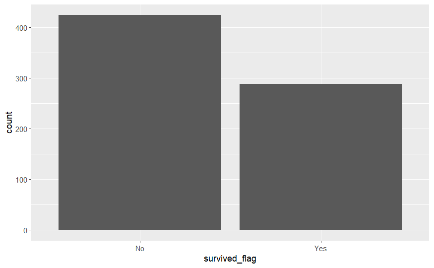

```r
titanic_clean %>%
  ggplot(aes(x = survived_flag)) +
  geom_bar()
```

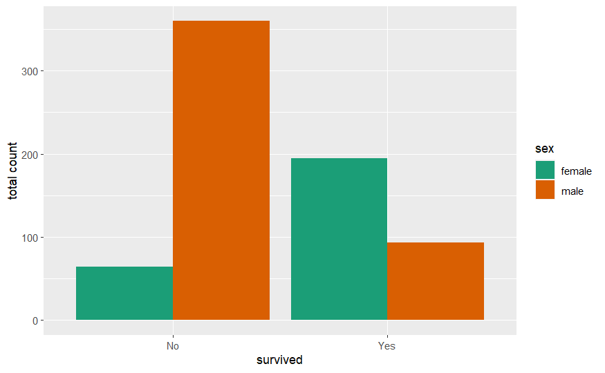

```r
titanic_clean %>%
  select(survived_flag, sex) %>%
  group_by(survived_flag,sex) %>%
  summarise(total_count = n()) %>%
  ggplot() +
  aes(x = survived_flag, y = total_count, fill = sex) +
  geom_bar(stat = "identity", position = position_dodge()) +
  scale_fill_brewer(palette="Dark2") +
  ylab("total count") + xlab("survived")
```

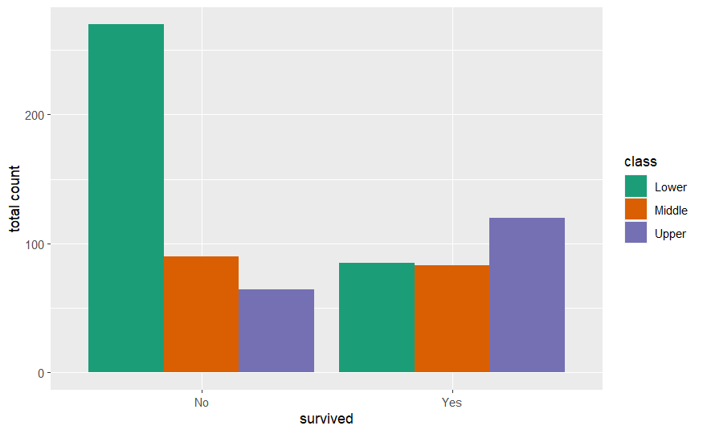

```r
titanic_clean %>%
  select(survived_flag, class) %>%
  group_by(survived_flag,class) %>%
  summarise(total_count = n()) %>%
  ggplot() +
  aes(x = survived_flag, y = total_count, fill = class) +
  geom_bar(stat = "identity", position = position_dodge()) +
  scale_fill_brewer(palette="Dark2") +
  ylab("total count") + xlab("survived")
```

## Question 2

Have a look at your data and create some plots to ensure you know what you’re working with before you begin. Write a summary of what you have found in your plots. Which variables do you think might be useful to predict whether or not people are going to die? Knowing this before you start is the best way to have a sanity check that your model is doing a good job.

```r
library(GGally)
```

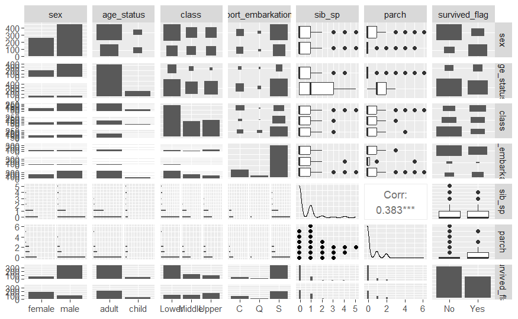

```r
ggpairs(titanic_clean, progress = FALSE)
```

`sex` and `class` seems to be the features that most influence the `survived_flag`. Even if it seems to be interesting to consider also the `age_status`.

## Question 3

Now you can start to build your model. Create your testing and training set using an appropriate split. Check you have balanced sets. Write down why you chose the split you did and produce output tables to show whether or not it is balanced. [Extra - if you want to force balanced testing and training sets, have a look at the stratified() function in package splitstackshape (you can specify multiple variables to stratify on by passing a vector of variable names to the group argument, and get back testing and training sets with argument bothSets = TRUE)]

```r
dim(titanic_clean)
```

```
[1] 712   7
```

```r
#set.seed(19)

#how many rows in total

n_data <- nrow(titanic_clean)

#create a test sample index
test_index <- sample(1:n_data, size = n_data*0.1)

# split the data
titanic_test <- slice(titanic_clean, test_index)
titanic_train <- slice(titanic_clean, -test_index)


?set.seed
```

I choose a split of 90-10 since the cleaned dataset contains 712 rows, which seems to me to be a not so much high number!

```r
titanic_test %>%
  janitor::tabyl(survived_flag)
```

```
 survived_flag  n   percent
            No 36 0.5070423
           Yes 35 0.4929577
```

```r
titanic_train %>%
  janitor::tabyl(survived_flag)
```

```
 survived_flag   n   percent
            No 388 0.6053042
           Yes 253 0.3946958
```

## Question 4

Create your decision tree to try and predict survival probability using an appropriate method, and create a decision tree plot.

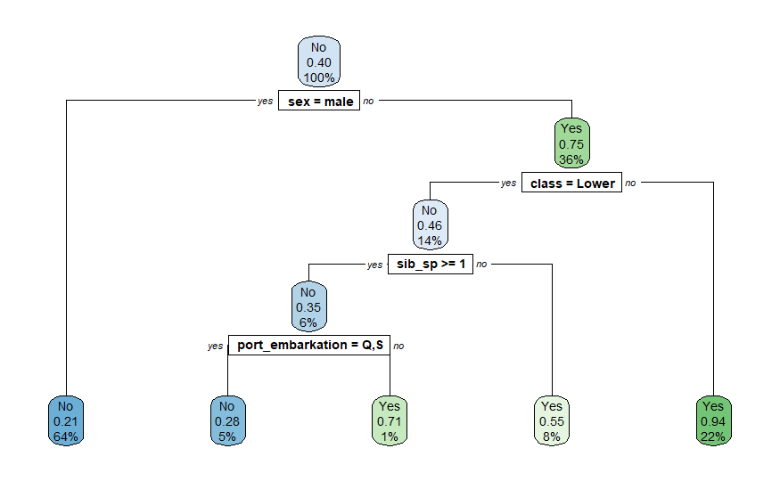

```r
# 1. make tree model

titanic_fit <- rpart(
  formula = survived_flag ~., #include all variables
  data = titanic_clean,
  method = "class" # for a categorical predictor
)

# 2. plot tree model

rpart.plot(titanic_fit,
           yesno = 2, # this writes yes/no at all splits
           type = 2, #dictates where our conditions lie at each node
           fallen.leaves = TRUE, # TRUE means leaves all alligned at bottom
           faclen = 6, #length of factor names
           digits = 2, # how many decimal places is prob reported in
           split.border.col = 1 #colour
           )
```

I used the method `class` since `survived_flag` is categorical.

## Question 5

Write down what this tells you, in detail. What variables are important? What does each node tell you? Who has the highest chance of surviving? Who has the lowest? Provide as much detail as you can.

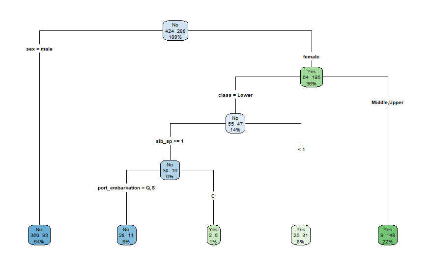

```r
rpart.plot(titanic_fit, yesno = 2, type = 4, extra = 101)
```

## Question 6

Test and add your predictions to your data. Create a confusion matrix. Write down in detail what this tells you for this specific dataset.

```r
titanic_pred <- titanic_test %>%
 add_predictions(titanic_fit, type = 'class')
```

```r
titanic_pred %>%
              conf_mat(truth = survived_flag, estimate = pred)
```

```
          Truth
Prediction No Yes
       No  28  14
       Yes  8  21
```

```r
accuracy <- titanic_pred %>%
 accuracy(truth = survived_flag, estimate = pred)

accuracy
```

| .metric | .estimator | .estimate |
| --- | --- | --- |
| accuracy | binary | 0.6901408 |

```r
sensitivity <- titanic_pred %>%
 sensitivity(truth = survived_flag, estimate = pred)

sensitivity
```

| .metric | .estimator | .estimate |
| --- | --- | --- |
| sensitivity | binary | 0.7777778 |

```r
specificity <- titanic_pred %>%
 specificity(truth = survived_flag, estimate = pred)

specificity
```

| .metric | .estimator | .estimate |
| --- | --- | --- |
| specificity | binary | 0.6 |